# Design 1: Inequality Belief Systems and Attitude Towards Redistribution in US and the Netherlands

# Input

| variable | label |
| --- | --- |
| p_income | Differences in income in the United States are too large |
| p_wealth | Differences in wealth in the United States are too large |
| p_poor | Children in poor families do not have the same opportunities for getting ahead a |
| p_black | Black children do not have the same opportunities for getting ahead as white chi |
| b_merit | Society is fair when hard-working people earn more than others |
| b_diversity | Racial diversity makes America stronger |
| b_equality | For society to be fair, differences in people’s standard of living should be sma |
| ib_weafam | coming from a wealthy family |
| ib_edupar | having highly educated parents |
| ib_edu | having a good education |
| ib_work | hard work |
| ib_people | knowing the right people |
| ib_race | race or skin color |
| ib_migra | legal or immigration status |
| ib_relig | religion |
| ib_sex | being born a man or woman |
| att_redist | It is the responsibility of the government to reduce the differences in income b |

# Processing

## Descriptives

### US

```
##
## ============================================
## Statistic         N   Mean  St. Dev. Min Max
## --------------------------------------------
## p_income        2,480 5.730  1.403    1   7
## p_wealth        2,480 5.888  1.420    1   7
## p_poor          2,480 5.970  1.364    1   7
## p_black         2,480 5.321  1.700    1   7
## b_merit         2,480 4.921  1.391    1   7
## b_diversity     2,480 5.740  1.457    1   7
## b_equality      2,480 4.884  1.576    1   7
## ib_weafam       2,480 3.510  0.979    1   5
## ib_edupar       2,480 3.411  0.931    1   5
## ib_edu          2,480 4.052  0.790    1   5
## ib_work         2,480 4.048  0.954    1   5
## ib_people       2,480 3.857  0.924    1   5
## ib_race         2,480 2.904  1.179    1   5
## ib_migra        2,480 3.567  1.070    1   5
## ib_relig        2,480 2.002  1.031    1   5
## ib_sex          2,480 2.714  1.163    1   5
## att_redist      2,480 4.950  1.844    1   7
## agegroups       2,480 3.051  1.502    1   5
## education       2,480 2.583  0.682    1   3
## working         2,480 0.650  0.477    0   1
## assets          2,480 3.139  1.909    0   7
## hhincome_groups 2,480 2.200  0.651    1   3
## immigrant       2,480 0.075  0.264    0   1
## marital         2,480 0.473  0.499    0   1
## --------------------------------------------
```

### NL

```
##
## ============================================
## Statistic         N   Mean  St. Dev. Min Max
## --------------------------------------------
## p_income        1,453 5.021  1.404    1   7
## p_wealth        1,453 5.185  1.396    1   7
## p_poor          1,453 5.240  1.344    1   7
## p_black         1,453 4.634  1.493    1   7
## b_merit         1,453 3.381  1.596    1   7
## b_diversity     1,453 3.668  1.574    1   7
## b_equality      1,453 4.380  1.491    1   7
## ib_weafam       1,453 2.855  0.863    1   5
## ib_edupar       1,453 3.163  0.763    1   5
## ib_edu          1,453 3.696  0.713    1   5
## ib_work         1,453 3.690  0.783    1   5
## ib_people       1,453 3.488  0.760    1   5
## ib_race         1,453 2.492  0.953    1   5
## ib_migra        1,453 2.601  0.926    1   5
## ib_relig        1,453 1.834  0.754    1   5
## ib_sex          1,453 2.194  0.885    1   5
## att_redist      1,453 5.039  1.457    1   7
## agegroups       1,453 4.082  1.282    1   5
## education       1,453 2.336  0.884    1   3
## working         1,453 0.429  0.495    0   1
## assets          1,453 3.387  1.401    0   7
## hhincome_groups 1,453 1.724  0.544    1   3
## immigrant       1,453 0.079  0.270    0   1
## marital         1,453 0.567  0.496    0   1
## --------------------------------------------
```

## CCA

### US

```
## Filtering out correlations for which Pr(|r| != 0) >  0.01
## CCA found 3 schematic classes. Sizes: 1169 1 1310
## NOTE: result contains 1 degenerate class(es): #2.
```

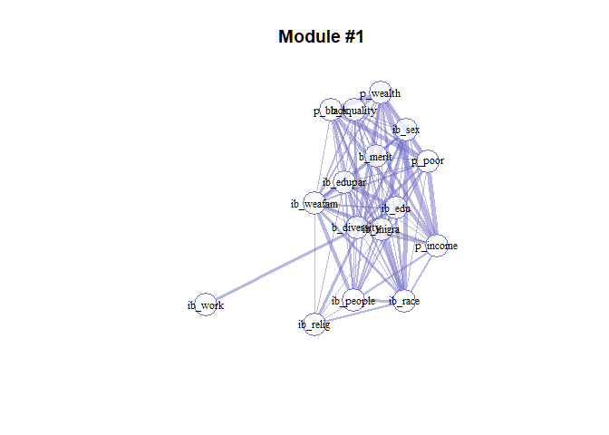

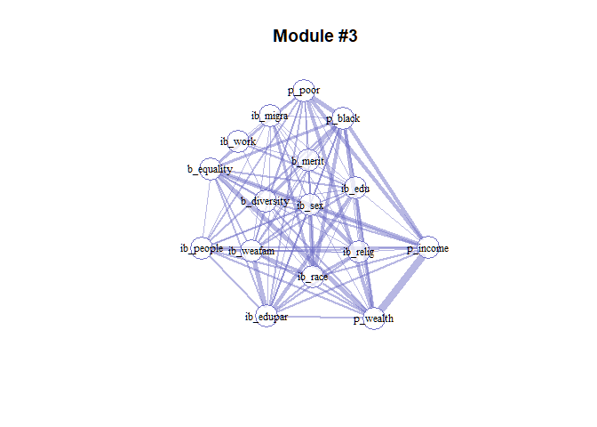

```r
#Rename CCA groups
data_us = data_us %>%
  mutate(cca = ifelse(cca=="3", 0, 1))

data_us_cca = data_us_cca %>%
  mutate(cca = ifelse(cca=="3", 0, 1))
```

### NL

```
## Filtering out correlations for which Pr(|r| != 0) >  0.01
## CCA found 3 schematic classes. Sizes: 759 1 693
## NOTE: result contains 1 degenerate class(es): #2.
```

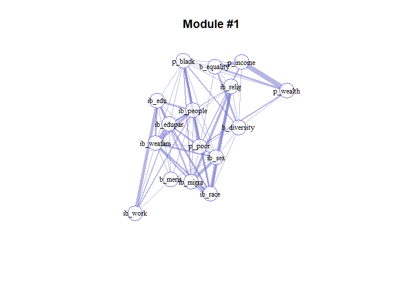

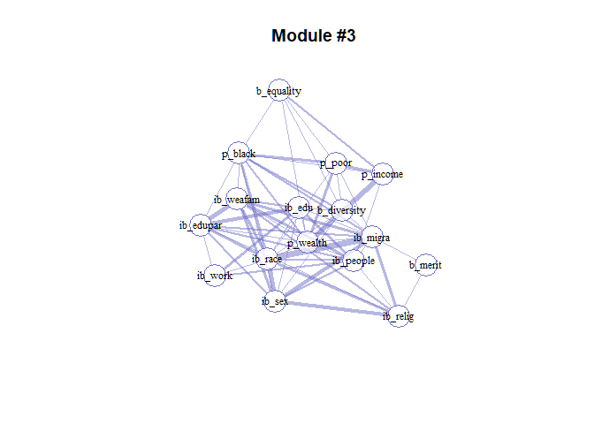

```r
#Rename CCA groups

data_nl = data_nl %>%
  mutate(cca = ifelse(cca=="3", 1, 0))

data_nl_cca = data_nl_cca %>%
  mutate(cca = ifelse(cca=="3", 1, 0))
```

## EGA

### US

### NL

### Plots

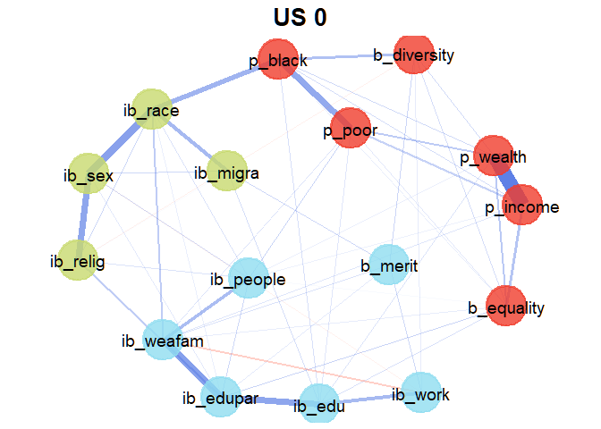

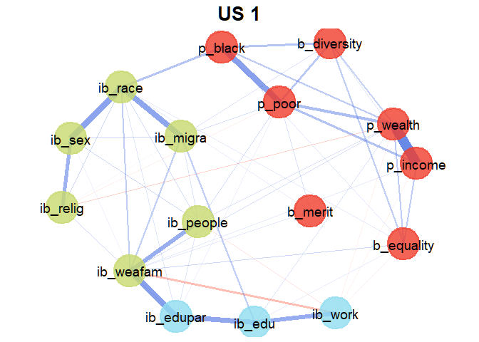

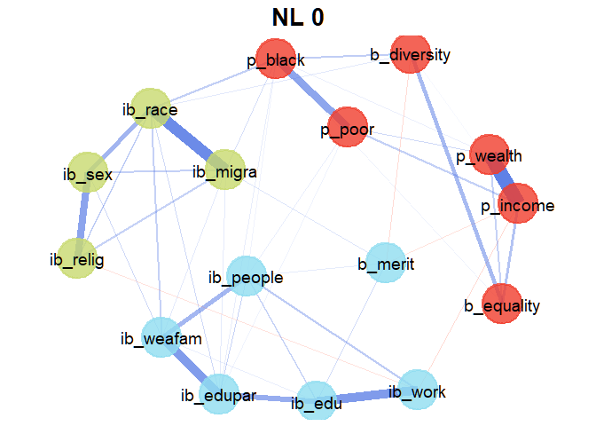

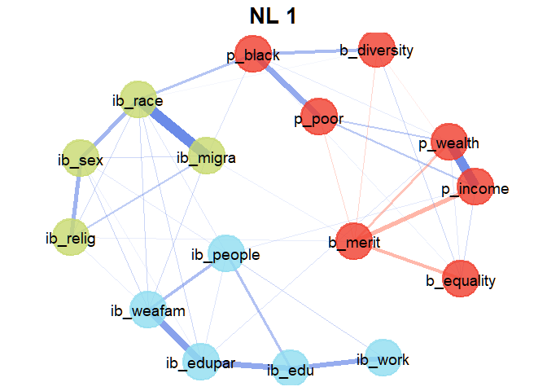

### NCT

#### US

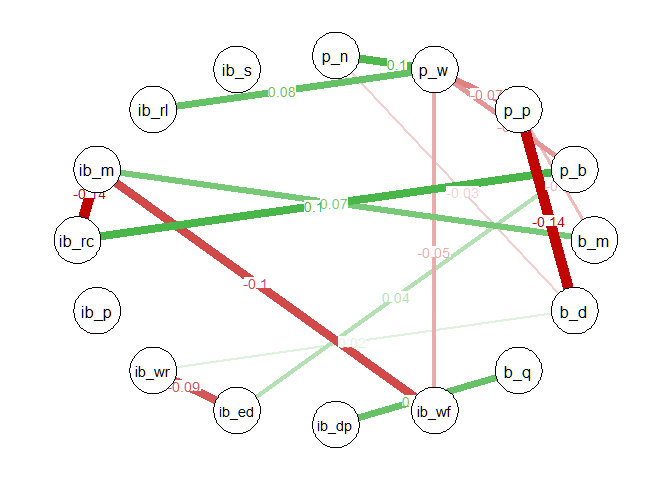

#### NL

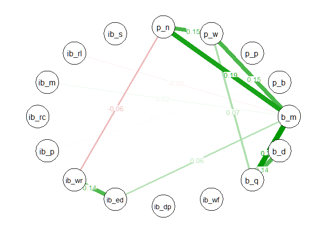

## Sociodemographic Determinants of Inequality Belief Systems

### US

### NL

Table. Logistic regression models on inequality belief membership - US & NL

M1-US

M2-US

M3-US

M1-NL

M2-NL

M3-NL

Odds Ratios

Odds Ratios

Odds Ratios

Odds Ratios

Odds Ratios

Odds Ratios

(Intercept)

3.48 ***  
(2.99 – 4.05)

2.75 ***  
(1.72 – 4.42)

0.72  
(0.47 – 1.09)

3.28 ***  
(2.44 – 4.43)

3.66 ***  
(1.82 – 7.39)

0.93  
(0.50 – 1.71)

politics

0.69 ***  
(0.67 – 0.72)

0.71 ***  
(0.68 – 0.74)

0.78 ***  
(0.74 – 0.82)

0.78 ***  
(0.73 – 0.82)

agegroups28-37

1.15  
(0.86 – 1.54)

1.16  
(0.88 – 1.52)

0.86  
(0.48 – 1.55)

0.85  
(0.48 – 1.51)

agegroups38-47

1.61 ***  
(1.17 – 2.22)

1.43 **  
(1.07 – 1.92)

1.07  
(0.59 – 1.93)

1.05  
(0.59 – 1.86)

agegroups48-57

1.36 *  
(0.97 – 1.90)

1.34 *  
(0.98 – 1.83)

1.05  
(0.60 – 1.84)

1.09  
(0.63 – 1.87)

agegroups58+

1.65 ***  
(1.23 – 2.22)

1.55 ***  
(1.18 – 2.03)

1.25  
(0.74 – 2.12)

1.41  
(0.85 – 2.35)

sexMale

0.87  
(0.72 – 1.04)

0.70 ***  
(0.59 – 0.83)

1.33 **  
(1.05 – 1.69)

1.18  
(0.94 – 1.49)

raceWhite

0.85  
(0.68 – 1.05)

0.73 ***  
(0.60 – 0.90)

1.06  
(0.70 – 1.61)

1.04  
(0.69 – 1.55)

educationSome college

1.46 **  
(1.04 – 2.05)

1.61 ***  
(1.18 – 2.21)

0.69 *  
(0.46 – 1.03)

0.73  
(0.49 – 1.08)

educationCollege or more

1.65 ***  
(1.21 – 2.26)

1.93 ***  
(1.44 – 2.58)

0.86  
(0.66 – 1.12)

0.93  
(0.72 – 1.20)

working

0.92  
(0.74 – 1.14)

0.87  
(0.72 – 1.07)

0.80  
(0.60 – 1.06)

0.77 *  
(0.58 – 1.01)

assets

0.93 **  
(0.88 – 0.99)

0.96  
(0.91 – 1.01)

0.98  
(0.90 – 1.07)

0.95  
(0.87 – 1.04)

hhincome_groupsMedium

0.60 ***  
(0.44 – 0.80)

0.66 ***  
(0.50 – 0.86)

1.01  
(0.77 – 1.33)

1.10  
(0.84 – 1.43)

hhincome_groupsHigh

0.51 ***  
(0.36 – 0.71)

0.53 ***  
(0.39 – 0.73)

0.51 **  
(0.27 – 0.94)

0.55 *  
(0.30 – 0.99)

immigrant

0.80  
(0.57 – 1.12)

0.87  
(0.63 – 1.20)

0.79  
(0.50 – 1.25)

0.88  
(0.56 – 1.37)

marital

0.98  
(0.79 – 1.22)

0.81 **  
(0.66 – 0.98)

1.01  
(0.79 – 1.30)

0.97  
(0.76 – 1.23)

religionNone

2.15 ***  
(1.66 – 2.81)

3.28 ***  
(2.58 – 4.18)

0.91  
(0.65 – 1.27)

1.05  
(0.76 – 1.46)

religionOther

1.45 **  
(1.08 – 1.95)

1.69 ***  
(1.29 – 2.21)

0.88  
(0.38 – 2.01)

1.17  
(0.52 – 2.61)

religionProtestant

1.35 **  
(1.01 – 1.80)

1.14  
(0.88 – 1.48)

1.01  
(0.67 – 1.53)

1.00  
(0.67 – 1.50)

Observations

2480

2480

2480

1453

1453

1453

R<sup>2</sup> Tjur

0.204

0.238

0.097

0.060

0.084

0.028

AIC

2891.386

2824.547

3216.832

1926.548

1922.912

2005.685

- p<0.1 ** p<0.05 *** p<0.01

## Inequality Belief Systems and Attitude Towards Redistribution

### Graphs

#### US

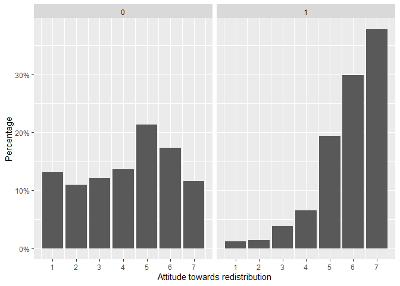

#### NL

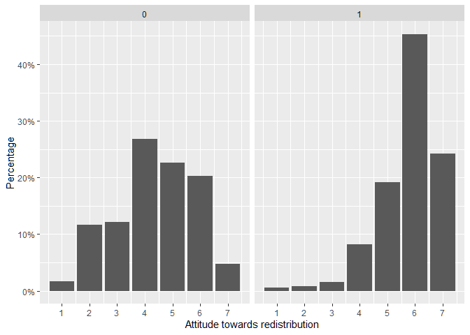

### Regressions

We have different ways to do the final regression (cca variable + predictors -> att_redis).

#### Design A: Based on EGA communities

First solution: We fit EGA on the full samples US and NL; we create means indexes starting from EGA groups; we do this because we rely on this: “we can state the following relationship as a fundamental rule of network psychometrics: Clusters in network = latent variables.” [Paper link](https://journals.plos.org/plosone/article?id=10.1371/journal.pone.0174035). However, here we have a problem, since these indexes have poor Cronbach alpha, and if we try to fit this structure with a CFA we have poor fit too. Therefore if we go on with this route we can say we are estimating mean indexes of each community, but it is hard to state we are building mean indexes of latent factor. Still, if we take this route we have the best regression results (CCA variable significant, increase in R2, only for NL)

##### EGA by country

##### Indexes

```r
#Indexes
data_us = data_us %>%
    mutate(index_1 = rowMeans(across(c(p_income, p_wealth, p_poor, p_black, b_diversity, b_equality))),
           index_2 = rowMeans(across(c(b_merit, ib_weafam, ib_edu, ib_edupar, ib_work, ib_people))),
           index_3 = rowMeans(across(c(ib_race, ib_migra, ib_relig, ib_sex))))


data_nl = data_nl %>%
    mutate(index_1 = rowMeans(across(c(p_income, p_wealth, p_poor, p_black, b_merit, b_diversity, b_equality))),
           index_2 = rowMeans(across(c(ib_weafam, ib_edu, ib_edupar, ib_work, ib_people))),
           index_3 = rowMeans(across(c(ib_race, ib_migra, ib_relig, ib_sex))))

#Cronbach
cronbach.alpha(index_1_us, CI=TRUE, standardized=TRUE) # 0.858
```

```
##
## Standardized Cronbach's alpha for the 'index_1_us' data-set
##
## Items: 6
## Sample units: 2480
## alpha: 0.858
##
## Bootstrap 95% CI based on 1000 samples
##  2.5% 97.5%
## 0.848 0.868
```

```r
cronbach.alpha(index_2_us, CI=TRUE, standardized=TRUE) # 0.456
```

```
##
## Standardized Cronbach's alpha for the 'index_2_us' data-set
##
## Items: 6
## Sample units: 2480
## alpha: 0.456
##
## Bootstrap 95% CI based on 1000 samples
##  2.5% 97.5%
## 0.417 0.493
```

```r
cronbach.alpha(index_3_us, CI=TRUE, standardized=TRUE) # 0.735
```

```
##
## Standardized Cronbach's alpha for the 'index_3_us' data-set
##
## Items: 4
## Sample units: 2480
## alpha: 0.735
##
## Bootstrap 95% CI based on 1000 samples
##  2.5% 97.5%
## 0.718 0.754
```

```r
cronbach.alpha(index_1_nl, CI=TRUE, standardized=TRUE) # 0.761
```

```
##
## Standardized Cronbach's alpha for the 'index_1_nl' data-set
##
## Items: 7
## Sample units: 2480
## alpha: 0.761
##
## Bootstrap 95% CI based on 1000 samples
##  2.5% 97.5%
## 0.748 0.774
```

```r
cronbach.alpha(index_2_nl, CI=TRUE, standardized=TRUE) # 0.512
```

```
##
## Standardized Cronbach's alpha for the 'index_2_nl' data-set
##
## Items: 5
## Sample units: 2480
## alpha: 0.512
##
## Bootstrap 95% CI based on 1000 samples
##  2.5% 97.5%
## 0.479 0.545
```

```r
cronbach.alpha(index_3_nl, CI=TRUE, standardized=TRUE) # 0.735
```

```
##
## Standardized Cronbach's alpha for the 'index_3_nl' data-set
##
## Items: 4
## Sample units: 2480
## alpha: 0.735
##
## Bootstrap 95% CI based on 1000 samples
##  2.5% 97.5%
## 0.716 0.753
```

##### Regressions

Table. Linear regression models on attitude towards redistribution - US & NL

M1-US

M2-US

M3-US

M4-US

M1-NL

M2-NL

M3-NL

M4-NL

Estimates

Estimates

Estimates

Estimates

Estimates

Estimates

Estimates

Estimates

(Intercept)

4.17 ***  
(4.08 – 4.26)

-2.30 ***  
(-2.71 – -1.89)

-2.32 ***  
(-2.73 – -1.90)

-0.54 **  
(-1.04 – -0.03)

4.37 ***  
(4.28 – 4.46)

-1.03 ***  
(-1.53 – -0.54)

-0.27  
(-0.72 – 0.18)

0.95 ***  
(0.36 – 1.53)

cca

1.65 ***  
(1.52 – 1.78)

0.12 *  
(-0.01 – 0.25)

0.09  
(-0.04 – 0.22)

1.41 ***  
(1.28 – 1.54)

0.99 ***  
(0.88 – 1.10)

0.90 ***  
(0.79 – 1.01)

index_1

1.17 ***  
(1.12 – 1.21)

1.14 ***  
(1.09 – 1.20)

1.01 ***  
(0.95 – 1.07)

1.35 ***  
(1.27 – 1.43)

1.18 ***  
(1.11 – 1.26)

1.07 ***  
(0.99 – 1.16)

index_2

0.07  
(-0.03 – 0.16)

0.11 *  
(-0.00 – 0.21)

0.03  
(-0.07 – 0.14)

0.02  
(-0.10 – 0.13)

-0.06  
(-0.17 – 0.04)

-0.03  
(-0.13 – 0.08)

index_3

0.17 ***  
(0.10 – 0.23)

0.14 ***  
(0.07 – 0.21)

0.18 ***  
(0.12 – 0.25)

-0.03  
(-0.11 – 0.06)

-0.12 ***  
(-0.20 – -0.04)

-0.12 ***  
(-0.20 – -0.04)

agegroups28-37

-0.11  
(-0.25 – 0.04)

-0.06  
(-0.33 – 0.22)

agegroups38-47

-0.17 **  
(-0.33 – -0.01)

0.01  
(-0.26 – 0.29)

agegroups48-57

-0.60 ***  
(-0.76 – -0.43)

0.04  
(-0.22 – 0.29)

agegroups58+

-0.67 ***  
(-0.81 – -0.52)

0.02  
(-0.22 – 0.26)

sexMale

0.12 **  
(0.02 – 0.21)

0.06  
(-0.05 – 0.17)

raceWhite

-0.04  
(-0.15 – 0.07)

-0.15  
(-0.34 – 0.05)

educationSome college

0.10  
(-0.07 – 0.27)

-0.34 ***  
(-0.53 – -0.15)

educationCollege or more

0.07  
(-0.08 – 0.23)

-0.22 ***  
(-0.35 – -0.10)

working

0.03  
(-0.07 – 0.14)

-0.12 *  
(-0.25 – 0.01)

politics

-0.07 ***  
(-0.09 – -0.05)

-0.08 ***  
(-0.11 – -0.05)

hhincome_groupsMedium

-0.25 ***  
(-0.40 – -0.11)

0.06  
(-0.07 – 0.18)

hhincome_groupsHigh

-0.24 ***  
(-0.40 – -0.07)

-0.49 ***  
(-0.76 – -0.21)

immigrant

-0.00  
(-0.18 – 0.18)

-0.05  
(-0.26 – 0.17)

marital

0.12 **  
(0.01 – 0.22)

-0.07  
(-0.18 – 0.04)

religionNone

-0.20 ***  
(-0.33 – -0.06)

-0.05  
(-0.21 – 0.10)

religionOther

-0.22 ***  
(-0.37 – -0.07)

-0.18  
(-0.56 – 0.20)

religionProtestant

-0.32 ***  
(-0.46 – -0.18)

0.01  
(-0.19 – 0.20)

Observations

2480

2480

2480

2480

1453

1453

1453

1453

R<sup>2</sup> / R<sup>2</sup> adjusted

0.200 / 0.200

0.576 / 0.576

0.577 / 0.576

0.614 / 0.611

0.233 / 0.233

0.426 / 0.425

0.530 / 0.529

0.558 / 0.552

AIC

9523.707

7951.101

7949.939

7756.660

4836.315

4418.525

4131.320

4074.423

- p<0.1 ** p<0.05 *** p<0.01

#### Design B: Based on EFA factors

Second route: since EGA did not retrieve a decent data structure (poor alpha, poor fit) we can do two factor analysis, one in NL one in US. If we do this we end up with a set of indexes. Later, we can put all these indexes and variables in the regression. Results say we have a significant effect of the CCA variable and an increase in the R2, but only for NL. Additionally, Cronbach alphas still present super low values in some indexes.

##### Factors

###### US

```
## Kaiser-Meyer-Olkin factor adequacy
## Call: KMO(r = data_us_net)
## Overall MSA =  0.85
## MSA for each item =
##    p_income    p_wealth      p_poor     p_black     b_merit b_diversity
##        0.81        0.81        0.91        0.89        0.82        0.92
##  b_equality   ib_weafam   ib_edupar      ib_edu     ib_work   ib_people
##        0.96        0.85        0.78        0.60        0.78        0.93
##     ib_race    ib_migra    ib_relig      ib_sex
##        0.86        0.85        0.77        0.87
```

```
## $chisq
## [1] 15897.6
##
## $p.value
## [1] 0
##
## $df
## [1] 120
```

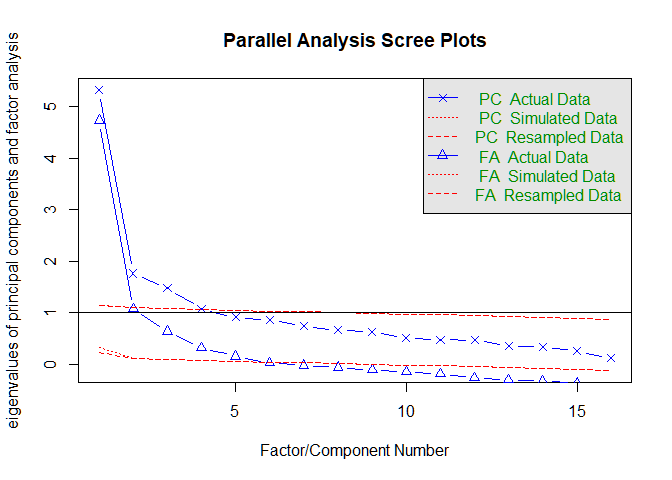

```
## Parallel analysis suggests that the number of factors =  5  and the number of components =  3
```

```
##
##   Estimator                                         ML
##   Rotation method                      OBLIMIN OBLIQUE
##   Oblimin gamma                                      0
##   Rotation algorithm (rstarts)                GPA (30)
##   Standardized metric                             TRUE
##   Row weights                                     None
##
##   Number of observations                          2480
##
## Fit measures:
##                     aic      bic    sabic   chisq df pvalue   cfi rmsea
##   nfactors = 5 110405.8 110905.9 110632.7 439.837 50      0 0.975 0.056
##
## Eigenvalues correlation matrix:
##
##     ev1     ev2     ev3     ev4     ev5     ev6     ev7     ev8     ev9    ev10
##   5.326   1.766   1.483   1.079   0.915   0.855   0.743   0.662   0.623   0.515
##    ev11    ev12    ev13    ev14    ev15    ev16
##   0.482   0.470   0.360   0.341   0.261   0.120
##
## Standardized loadings: (* = significant at 1% level)
##
##                 f1      f2      f3      f4      f5       unique.var
## p_income     0.947*      .       .       .       .            0.116
## p_wealth     0.926*      .       .       .*      .            0.126
## p_poor       0.243*  0.527*      .*      .       .*           0.466
## p_black          .   0.870*      .       .       .*           0.182
## b_merit          .*      .*      .       .*      .*           0.909
## b_diversity      .*  0.383*      .       .       .            0.788
## b_equality   0.465*      .*      .*      .       .*           0.604
## ib_weafam        .       .   0.840*      .*      .            0.270
## ib_edupar        .       .   0.581*  0.325*      .*           0.453
## ib_edu           .*      .*      .*  0.771*      .            0.363
## ib_work          .*      .* -0.310*  0.490*      .*           0.630
## ib_people        .*      .   0.384*      .       .*           0.715
## ib_race          .   0.260*      .*      .   0.639*           0.293
## ib_migra         .*      .       .*      .*  0.474*           0.710
## ib_relig         .       .*      .       .   0.570*           0.739
## ib_sex           .*      .       .       .   0.801*           0.329
```

[output cut: 17 more lines]

```
##
##                               f1    f5    f2    f3    f4 total
## Sum of sq (obliq) loadings 2.333 1.847 1.582 1.546 0.999 8.306
## Proportion of total        0.281 0.222 0.190 0.186 0.120 1.000
## Proportion var             0.146 0.115 0.099 0.097 0.062 0.519
## Cumulative var             0.146 0.261 0.360 0.457 0.519 0.519
##
## Factor correlations: (* = significant at 1% level)
##
##        f1      f2      f3      f4      f5
## f1  1.000
## f2  0.681*  1.000
## f3  0.409*  0.394*  1.000
## f4  0.043   0.013   0.193*  1.000
## f5  0.355*  0.483*  0.490*  0.030   1.000
```

```r
#Indexes
data_us = data_us %>%
    mutate(index_1 = rowMeans(across(c(p_income, p_wealth, b_equality))),
           index_2 = rowMeans(across(c(p_poor, p_black, b_diversity))),
           index_3 = rowMeans(across(c(ib_weafam, ib_edupar, ib_people))),
           index_4 = rowMeans(across(c(ib_edu, ib_work))),
           index_5 = rowMeans(across(c(ib_race, ib_migra, ib_relig, ib_sex))))


factor_us1 = data_us_net %>%
  select(p_income, p_wealth, b_equality)

factor_us2 = data_us_net %>%
  select(p_poor, p_black, b_diversity)

factor_us3 = data_us_net %>%
  select(ib_weafam, ib_edupar, ib_people)

factor_us4 = data_us_net %>%
  select(ib_edu, ib_work)

factor_us5 = data_us_net %>%
  select(ib_race, ib_migra, ib_relig, ib_sex)


#Cronbach
cronbach.alpha(factor_us1, CI=TRUE, standardized=TRUE) # 0.859
```

```
##
## Standardized Cronbach's alpha for the 'factor_us1' data-set
##
## Items: 3
## Sample units: 2480
## alpha: 0.859
##
## Bootstrap 95% CI based on 1000 samples
##  2.5% 97.5%
## 0.845 0.871
```

```r
cronbach.alpha(factor_us2, CI=TRUE, standardized=TRUE) # 0.709
```

```
##
## Standardized Cronbach's alpha for the 'factor_us2' data-set
##
## Items: 3
## Sample units: 2480
## alpha: 0.709
##
## Bootstrap 95% CI based on 1000 samples
##  2.5% 97.5%
## 0.684 0.732
```

```r
cronbach.alpha(factor_us3, CI=TRUE, standardized=TRUE) # 0.698
```

```
##
## Standardized Cronbach's alpha for the 'factor_us3' data-set
##
## Items: 3
## Sample units: 2480
## alpha: 0.698
##
## Bootstrap 95% CI based on 1000 samples
##  2.5% 97.5%
## 0.672 0.721
```

```r
cronbach.alpha(factor_us4, CI=TRUE, standardized=TRUE) # 0.430
```

```
##
## Standardized Cronbach's alpha for the 'factor_us4' data-set
##
## Items: 2
## Sample units: 2480
## alpha: 0.43
##
## Bootstrap 95% CI based on 1000 samples
##  2.5% 97.5%
## 0.381 0.479
```

```r
cronbach.alpha(factor_us5, CI=TRUE, standardized=TRUE) # 0.735
```

```
##
## Standardized Cronbach's alpha for the 'factor_us5' data-set
##
## Items: 4
## Sample units: 2480
## alpha: 0.735
##
## Bootstrap 95% CI based on 1000 samples
##  2.5% 97.5%
## 0.715 0.754
```

###### NL

```
## Kaiser-Meyer-Olkin factor adequacy
## Call: KMO(r = data_nl_net)
## Overall MSA =  0.78
## MSA for each item =
##    p_income    p_wealth      p_poor     p_black     b_merit b_diversity
##        0.71        0.73        0.83        0.79        0.89        0.44
##  b_equality   ib_weafam   ib_edupar      ib_edu     ib_work   ib_people
##        0.87        0.82        0.79        0.71        0.62        0.85
##     ib_race    ib_migra    ib_relig      ib_sex
##        0.78        0.77        0.84        0.87
```

```
## $chisq
## [1] 8100.482
##
## $p.value
## [1] 0
##
## $df
## [1] 120
```

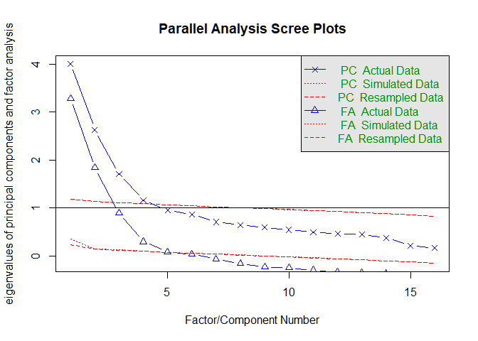

```
## Parallel analysis suggests that the number of factors =  4  and the number of components =  4
```

```
##
##   Estimator                                         ML
##   Rotation method                      OBLIMIN OBLIQUE
##   Oblimin gamma                                      0
##   Rotation algorithm (rstarts)                GPA (30)
##   Standardized metric                             TRUE
##   Row weights                                     None
##
##   Number of observations                          1453
##
## Fit measures:
##                     aic     bic    sabic   chisq df pvalue   cfi rmsea
##   nfactors = 4 61138.28 61529.1 61294.03 602.409 62      0 0.933 0.077
##
## Eigenvalues correlation matrix:
##
##     ev1     ev2     ev3     ev4     ev5     ev6     ev7     ev8     ev9    ev10
##   4.006   2.631   1.708   1.167   0.950   0.870   0.709   0.643   0.596   0.546
##    ev11    ev12    ev13    ev14    ev15    ev16
##   0.499   0.461   0.449   0.377   0.219   0.168
##
## Standardized loadings: (* = significant at 1% level)
##
##                 f1      f2      f3      f4       unique.var   communalities
## p_income     0.954*      .*      .       .            0.116           0.884
## p_wealth     0.865*      .       .*      .            0.235           0.765
## p_poor       0.341*  0.393*      .       .            0.651           0.349
## p_black          .   0.910*      .       .            0.161           0.839
## b_merit     -0.566*      .       .       .            0.661           0.339
## b_diversity      .   0.260*      .       .            0.939           0.061
## b_equality   0.490*      .*      .       .            0.720           0.280
## ib_weafam        .       .   0.482*  0.284*           0.583           0.417
## ib_edupar        .       .   0.620*      .*           0.516           0.484
## ib_edu           .       .   0.724*      .*           0.511           0.489
## ib_work          .*      .   0.498*      .*           0.764           0.236
## ib_people        .*      .   0.510*      .            0.699           0.301
## ib_race          .       .*      .   0.856*           0.205           0.795
## ib_migra         .       .       .   0.838*           0.294           0.706
## ib_relig         .       .*      .   0.578*           0.718           0.282
## ib_sex           .       .       .   0.639*           0.581           0.419
##
##                               f1    f4    f3    f2 total
## Sum of sq (obliq) loadings 2.438 2.372 1.711 1.126 7.647
## Proportion of total        0.319 0.310 0.224 0.147 1.000
## Proportion var             0.152 0.148 0.107 0.070 0.478
## Cumulative var             0.152 0.301 0.408 0.478 0.478
##
## Factor correlations: (* = significant at 1% level)
##
##        f1      f2      f3      f4
## f1  1.000
## f2  0.317*  1.000
## f3  0.073   0.144*  1.000
## f4  0.155*  0.366*  0.362*  1.000
```

```r
#Indexes
data_nl = data_nl %>%
    mutate(index_1 = rowMeans(across(c(p_income, p_wealth, b_merit, b_equality))),
           index_2 = rowMeans(across(c(p_poor, p_black, b_diversity))),
           index_3 = rowMeans(across(c(ib_weafam, ib_edupar, ib_people, ib_edu, ib_work))),
           index_4 = rowMeans(across(c(ib_race, ib_migra, ib_relig, ib_sex))))


factor_nl1 = data_nl_net %>%
  select(p_income, p_wealth, b_merit, b_equality)

factor_nl2 = data_nl_net %>%
  select(p_poor, p_black, b_diversity)

factor_nl3 = data_nl_net %>%
  select(ib_weafam, ib_edupar, ib_people, ib_edu, ib_work)

factor_nl4 = data_nl_net %>%
  select(ib_race, ib_migra, ib_relig, ib_sex)

#Cronbach
cronbach.alpha(factor_nl1, CI=TRUE, standardized=TRUE) # 0.166
```

```
##
## Standardized Cronbach's alpha for the 'factor_nl1' data-set
##
## Items: 4
## Sample units: 1453
## alpha: 0.166
##
## Bootstrap 95% CI based on 1000 samples
##  2.5% 97.5%
## 0.107 0.221
```

```r
cronbach.alpha(factor_nl2, CI=TRUE, standardized=TRUE) # 0.485
```

```
##
## Standardized Cronbach's alpha for the 'factor_nl2' data-set
##
## Items: 3
## Sample units: 1453
## alpha: 0.485
##
## Bootstrap 95% CI based on 1000 samples
##  2.5% 97.5%
## 0.431 0.531
```

```r
cronbach.alpha(factor_nl3, CI=TRUE, standardized=TRUE) # 0.713
```

```
##
## Standardized Cronbach's alpha for the 'factor_nl3' data-set
##
## Items: 5
## Sample units: 1453
## alpha: 0.713
##
## Bootstrap 95% CI based on 1000 samples
##  2.5% 97.5%
## 0.682 0.737
```

```r
cronbach.alpha(factor_nl4, CI=TRUE, standardized=TRUE) # 0.816
```

```
##
## Standardized Cronbach's alpha for the 'factor_nl4' data-set
##
## Items: 4
## Sample units: 1453
## alpha: 0.816
##
## Bootstrap 95% CI based on 1000 samples
##  2.5% 97.5%
## 0.795 0.835
```

##### Regression

Table. Linear regression models on attitude towards redistribution - US & NL

M1-US

M2-US

M3-US

M4-US

M1-NL

M2-NL

M3-NL

M4-NL

Estimates

Estimates

Estimates

Estimates

Estimates

Estimates

Estimates

Estimates

(Intercept)

4.17 ***  
(4.08 – 4.26)

-1.99 ***  
(-2.39 – -1.59)

-1.98 ***  
(-2.38 – -1.58)

-0.05  
(-0.57 – 0.46)

4.37 ***  
(4.28 – 4.46)

-1.45 ***  
(-1.94 – -0.96)

-0.65 ***  
(-1.10 – -0.19)

0.59 *  
(-0.00 – 1.18)

cca

1.65 ***  
(1.52 – 1.78)

0.07  
(-0.06 – 0.19)

0.07  
(-0.05 – 0.20)

1.41 ***  
(1.28 – 1.54)

0.95 ***  
(0.84 – 1.06)

0.86 ***  
(0.76 – 0.97)

index_1

0.74 ***  
(0.69 – 0.79)

0.74 ***  
(0.69 – 0.79)

0.67 ***  
(0.62 – 0.72)

1.05 ***  
(0.97 – 1.13)

0.91 ***  
(0.84 – 0.98)

0.83 ***  
(0.75 – 0.90)

index_2

0.38 ***  
(0.32 – 0.43)

0.37 ***  
(0.31 – 0.42)

0.31 ***  
(0.25 – 0.36)

0.37 ***  
(0.31 – 0.42)

0.34 ***  
(0.28 – 0.39)

0.30 ***  
(0.25 – 0.36)

index_3

0.17 ***  
(0.09 – 0.24)

0.17 ***  
(0.09 – 0.24)

0.08 **  
(0.01 – 0.16)

0.02  
(-0.09 – 0.13)

-0.06  
(-0.16 – 0.05)

-0.03  
(-0.13 – 0.08)

index_4

-0.06 *  
(-0.13 – 0.01)

-0.05  
(-0.12 – 0.03)

-0.02  
(-0.10 – 0.05)

0.02  
(-0.07 – 0.10)

-0.08 **  
(-0.16 – -0.00)

-0.09 **  
(-0.16 – -0.01)

index_5

0.13 ***  
(0.07 – 0.20)

0.12 ***  
(0.05 – 0.19)

0.18 ***  
(0.11 – 0.25)

age

-0.02 ***  
(-0.02 – -0.01)

0.00  
(-0.00 – 0.00)

sexMale

0.11 **  
(0.01 – 0.20)

0.05  
(-0.06 – 0.15)

raceWhite

-0.03  
(-0.14 – 0.08)

-0.15  
(-0.33 – 0.04)

educationSome college

0.13  
(-0.04 – 0.30)

-0.29 ***  
(-0.47 – -0.11)

educationCollege or more

0.12  
(-0.03 – 0.28)

-0.19 ***  
(-0.31 – -0.06)

working

0.00  
(-0.10 – 0.10)

-0.09  
(-0.22 – 0.04)

politics

-0.08 ***  
(-0.10 – -0.06)

-0.09 ***  
(-0.11 – -0.06)

hhincome_groupsMedium

-0.22 ***  
(-0.36 – -0.08)

0.07  
(-0.05 – 0.20)

hhincome_groupsHigh

-0.18 **  
(-0.35 – -0.02)

-0.36 ***  
(-0.63 – -0.09)

immigrant

-0.01  
(-0.18 – 0.17)

-0.01  
(-0.22 – 0.20)

marital

0.13 **  
(0.03 – 0.23)

-0.07  
(-0.18 – 0.03)

religionNone

-0.19 ***  
(-0.32 – -0.06)

-0.04  
(-0.19 – 0.11)

religionOther

-0.20 ***  
(-0.34 – -0.05)

-0.21  
(-0.59 – 0.16)

religionProtestant

-0.28 ***  
(-0.42 – -0.14)

0.02  
(-0.17 – 0.21)

Observations

2480

2480

2480

2480

1453

1453

1453

1453

R<sup>2</sup> / R<sup>2</sup> adjusted

0.200 / 0.200

0.591 / 0.590

0.591 / 0.590

0.624 / 0.621

0.233 / 0.233

0.456 / 0.454

0.549 / 0.548

0.574 / 0.568

AIC

9523.707

7869.394

7870.359

7691.646

4836.315

4344.032

4071.915

4019.207

- p<0.1 ** p<0.05 *** p<0.01

#### Design C: All variables included

Third route: we can attempt to run a regression with all the CCA variables (inequality beliefs + perceptions + beliefs). This route avoids problems related to the indexes, but is probably hampered by collinearity arising between CCA items. If we do this we have a non significant CCA coefficient, and adding CCA do not increase the R2 of the model.

Table. Linear regression models on attitude towards redistribution - US & NL

M1-US

M2-US

M3-US

M4-US

M1-NL

M2-NL

M3-NL

M4-NL

Estimates

Estimates

Estimates

Estimates

Estimates

Estimates

Estimates

Estimates

(Intercept)

4.17 ***  
(4.08 – 4.26)

-1.25 ***  
(-1.70 – -0.81)

-1.20 ***  
(-1.66 – -0.75)

0.54 *  
(-0.01 – 1.08)

4.37 ***  
(4.28 – 4.46)

0.80 ***  
(0.34 – 1.27)

0.82 ***  
(0.35 – 1.30)

1.60 ***  
(1.01 – 2.18)

cca

1.65 ***  
(1.52 – 1.78)

-0.07  
(-0.21 – 0.08)

-0.06  
(-0.20 – 0.08)

1.41 ***  
(1.28 – 1.54)

-0.04  
(-0.19 – 0.11)

-0.04  
(-0.20 – 0.11)

p_income

0.19 ***  
(0.12 – 0.26)

0.19 ***  
(0.12 – 0.26)

0.20 ***  
(0.14 – 0.27)

0.36 ***  
(0.30 – 0.42)

0.36 ***  
(0.30 – 0.42)

0.34 ***  
(0.28 – 0.40)

p_wealth

0.23 ***  
(0.16 – 0.30)

0.23 ***  
(0.16 – 0.30)

0.18 ***  
(0.12 – 0.25)

0.23 ***  
(0.18 – 0.29)

0.23 ***  
(0.18 – 0.29)

0.22 ***  
(0.16 – 0.28)

p_poor

0.04  
(-0.01 – 0.09)

0.04 *  
(-0.01 – 0.09)

0.03  
(-0.02 – 0.07)

0.08 ***  
(0.04 – 0.12)

0.08 ***  
(0.04 – 0.12)

0.08 ***  
(0.04 – 0.12)

p_black

0.30 ***  
(0.26 – 0.34)

0.31 ***  
(0.26 – 0.35)

0.27 ***  
(0.23 – 0.31)

0.12 ***  
(0.08 – 0.16)

0.12 ***  
(0.08 – 0.16)

0.12 ***  
(0.08 – 0.15)

b_merit

-0.01  
(-0.04 – 0.03)

-0.01  
(-0.05 – 0.02)

-0.01  
(-0.05 – 0.03)

-0.13 ***  
(-0.17 – -0.10)

-0.14 ***  
(-0.19 – -0.09)

-0.13 ***  
(-0.18 – -0.09)

b_diversity

0.02  
(-0.01 – 0.06)

0.02  
(-0.01 – 0.06)

0.01  
(-0.03 – 0.04)

0.06 ***  
(0.03 – 0.09)

0.06 ***  
(0.03 – 0.09)

0.05 ***  
(0.01 – 0.08)

b_equality

0.29 ***  
(0.25 – 0.32)

0.29 ***  
(0.25 – 0.33)

0.26 ***  
(0.22 – 0.29)

0.12 ***  
(0.09 – 0.16)

0.13 ***  
(0.09 – 0.16)

0.11 ***  
(0.08 – 0.15)

ib_weafam

0.00  
(-0.06 – 0.07)

0.00  
(-0.06 – 0.07)

0.01  
(-0.05 – 0.07)

-0.03  
(-0.10 – 0.04)

-0.03  
(-0.10 – 0.04)

-0.03  
(-0.09 – 0.04)

ib_edupar

0.07 **  
(0.01 – 0.14)

0.07 **  
(0.01 – 0.14)

0.05  
(-0.02 – 0.11)

0.03  
(-0.05 – 0.11)

0.03  
(-0.05 – 0.11)

0.01  
(-0.07 – 0.09)

ib_edu

0.08 **  
(0.01 – 0.15)

0.08 **  
(0.01 – 0.15)

0.09 **  
(0.02 – 0.15)

0.02  
(-0.06 – 0.10)

0.02  
(-0.06 – 0.10)

0.03  
(-0.05 – 0.11)

ib_work

-0.11 ***  
(-0.17 – -0.06)

-0.12 ***  
(-0.18 – -0.06)

-0.09 ***  
(-0.15 – -0.04)

-0.04  
(-0.11 – 0.03)

-0.04  
(-0.11 – 0.03)

-0.03  
(-0.10 – 0.04)

ib_people

0.05 *  
(-0.00 – 0.11)

0.05 *  
(-0.00 – 0.11)

-0.00  
(-0.06 – 0.05)

0.03  
(-0.04 – 0.10)

0.03  
(-0.04 – 0.10)

0.03  
(-0.04 – 0.10)

ib_race

-0.00  
(-0.07 – 0.06)

0.00  
(-0.06 – 0.06)

0.01  
(-0.05 – 0.07)

-0.04  
(-0.13 – 0.04)

-0.04  
(-0.13 – 0.04)

-0.05  
(-0.13 – 0.03)

ib_migra

-0.04 *  
(-0.09 – 0.01)

-0.04 *  
(-0.09 – 0.01)

-0.03  
(-0.08 – 0.02)

0.01  
(-0.07 – 0.09)

0.01  
(-0.07 – 0.09)

0.01  
(-0.06 – 0.09)

ib_relig

0.09 ***  
(0.04 – 0.14)

0.09 ***  
(0.04 – 0.14)

0.11 ***  
(0.06 – 0.17)

-0.00  
(-0.08 – 0.07)

-0.00  
(-0.08 – 0.07)

-0.00  
(-0.07 – 0.07)

ib_sex

0.02  
(-0.04 – 0.07)

0.02  
(-0.04 – 0.08)

0.04  
(-0.02 – 0.09)

0.01  
(-0.06 – 0.08)

0.01  
(-0.06 – 0.08)

0.00  
(-0.07 – 0.07)

age

-0.02 ***  
(-0.02 – -0.01)

-0.00  
(-0.00 – 0.00)

sexMale

0.10 **  
(0.01 – 0.19)

0.09 *  
(-0.01 – 0.19)

raceWhite

0.02  
(-0.09 – 0.12)

-0.10  
(-0.28 – 0.07)

educationSome college

0.11  
(-0.05 – 0.28)

-0.22 ***  
(-0.39 – -0.05)

educationCollege or more

0.10  
(-0.05 – 0.25)

-0.13 **  
(-0.24 – -0.01)

working

-0.00  
(-0.10 – 0.10)

-0.10  
(-0.21 – 0.02)

politics

-0.08 ***  
(-0.10 – -0.06)

-0.05 ***  
(-0.08 – -0.03)

hhincome_groupsMedium

-0.20 ***  
(-0.34 – -0.06)

0.06  
(-0.06 – 0.17)

hhincome_groupsHigh

-0.16 *  
(-0.32 – 0.00)

-0.22 *  
(-0.47 – 0.03)

immigrant

0.00  
(-0.17 – 0.18)

0.01  
(-0.18 – 0.20)

marital

0.10 *  
(-0.00 – 0.20)

-0.09 *  
(-0.19 – 0.01)

religionNone

-0.11  
(-0.24 – 0.02)

-0.04  
(-0.18 – 0.10)

religionOther

-0.13 *  
(-0.28 – 0.01)

-0.12  
(-0.47 – 0.22)

religionProtestant

-0.23 ***  
(-0.37 – -0.09)

0.07  
(-0.11 – 0.24)

Observations

2480

2480

2480

2480

1453

1453

1453

1453

R<sup>2</sup> / R<sup>2</sup> adjusted

0.200 / 0.200

0.613 / 0.610

0.613 / 0.610

0.642 / 0.638

0.233 / 0.233

0.638 / 0.634

0.638 / 0.634

0.650 / 0.642

AIC

9523.707

7755.375

7756.479

7587.349

4836.315

3776.084

3777.837

3756.901

- p<0.1 ** p<0.05 *** p<0.01